# PS03 pre-lecture: data wrangling with dplyr

## Data wrangling verbs

The native pipe `|>` and the verbs in the **dplyr** package

- `filter()`
- `summarize()`
- `group_by()`
- `mutate()`
- `arrange()`
- `inner_join()`
- `select()`

## The pipe operator

`|>`

Take this data frame, **then**… filter the data, **then** with those results… summarize

`|>` `|>`

- “Pipe” a data frame into a “verb” command
- “Chain” the results from one “verb” command into another
- Think of it as the word **“then”**

## filter()

Pull out just the **rows** you want in a data set, based on some criteria

## filter()

Example

the data frame

```r
on_time_flights <- flights |>
  filter(arr_delay < 30)
```

the verb (function) what column (variable) to use for filtering

only keep rows where the column meets this criterion

## filter()

Another example

the data frame

```r
newark_flights <- flights |>
  filter(origin == "EWR")
```

the verb (function) what column (variable) to use for filtering

only keep rows where the column meets this criterion

Comparisons: `==` `!=` `<` `>` `<=` `>=`, combined with `&` (and) or `|` (or)

## summarize()

Take a column of data from a data frame and reduce it down to a single summary statistic

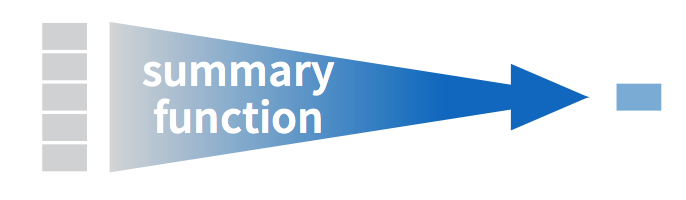

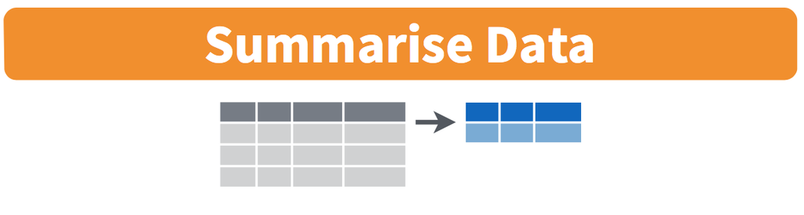

## summarize()

Example

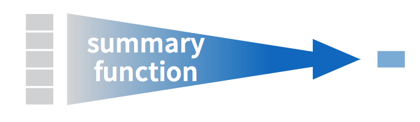

the data frame

```r
flights |>
  summarize(av_dist = mean(distance))
```

the verb (function) what to call the result the column to summarize

what summary statistic to calculate

## group_by() then summarize()

Take a column of data and reduce it down to a summary statistic, by some grouping variable

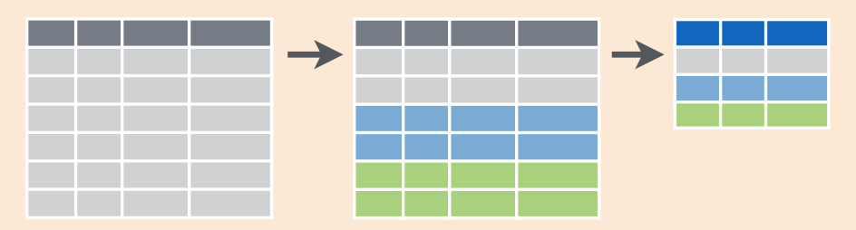

## group_by() then summarize()

Example

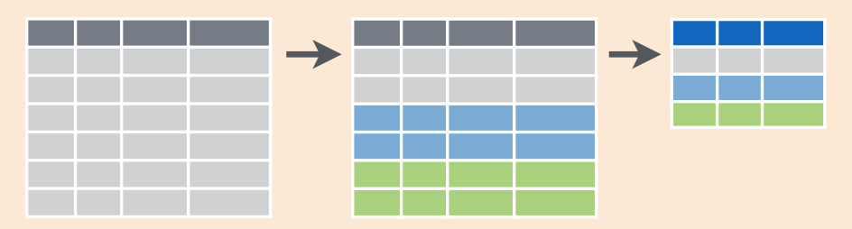

the data frame

```r
flights |>
  group_by(origin) |>
  summarize(av_dist = mean(distance))
```

the verb (function) what to call the result the column to summarize

group_by(), then what to group by

## mutate()

Add a new column to a data frame, computed from the columns already there

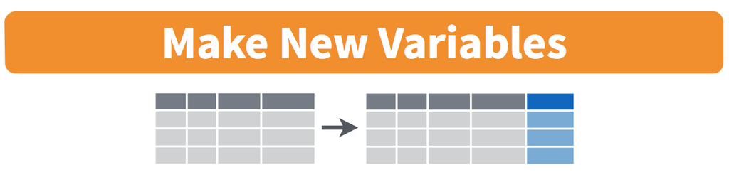

## mutate()

Example

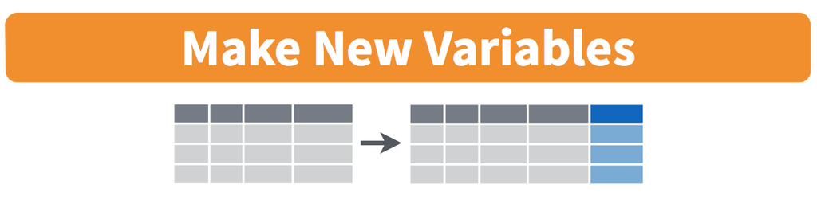

the data frame

```r
flights |>
  mutate(dist_km = distance * 1.609)
```

the verb (function) what to call the new column (new variable) what to put in the new column

## arrange()

Sort the **rows** of a data frame by the values in one of its columns

Arrange Rows

## arrange()

Example

the data frame

```r
freq_dest |>
  arrange(desc(num_flights))
```

the verb (function) which column to sort by, largest first

`freq_dest` has one row per destination and its number of flights, made with `group_by(dest)` and `summarize()`.

## inner_join()

Combine two data frames by matching **rows** on a key column, keeping only the keys found in both

Join Data Frames

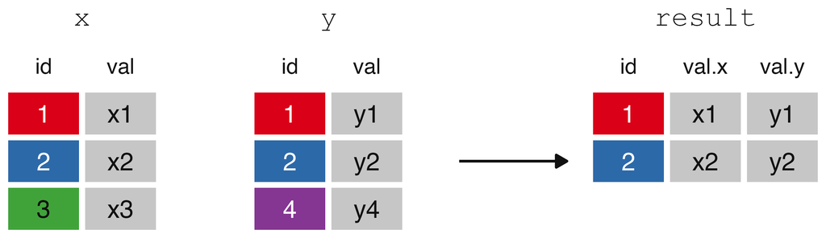

## inner_join()

Example

the data frame

```r
flights_joined <- flights |>
  inner_join(airlines, by = "carrier")
```

the verb (function) the second data frame the key column both share

## select()

Pull out just the **columns** you want in a data set, based on the column names

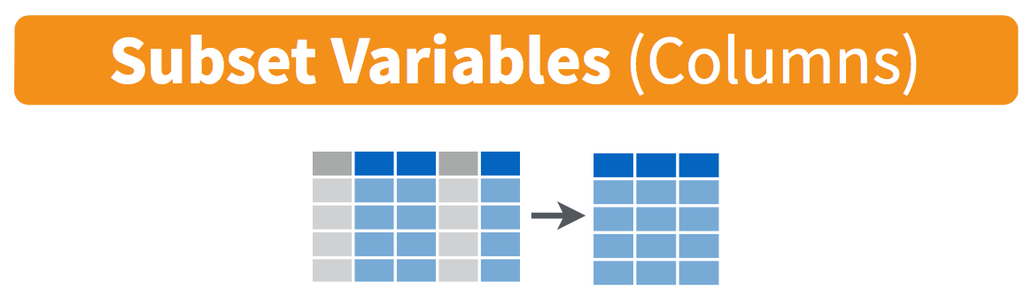

## select()

Example

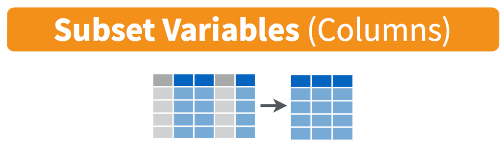

the data frame

```r
flights_sub <- flights |>
  select(arr_delay, dep_delay)
```

the verb (function) what columns (variables) to keep